# r_prg_midterm_03

陳韋哲

2017/1/22

## R程式設計班第三次期中作業：使用`ggplot2`繪製簡單的統計圖

說明： `diamonds`是`ggplot2`內的資料。共有53,940顆鑽石的克拉數(carat)、切工(cut)、顏色(color)、淨度(calrity)與價格(price)等資料。前6筆的資料如下。

```r
head(diamonds)
```

```
## # A tibble: 6 × 10
##   carat       cut color clarity depth table price     x     y     z
##   <dbl>     <ord> <ord>   <ord> <dbl> <dbl> <int> <dbl> <dbl> <dbl>
## 1  0.23     Ideal     E     SI2  61.5    55   326  3.95  3.98  2.43
## 2  0.21   Premium     E     SI1  59.8    61   326  3.89  3.84  2.31
## 3  0.23      Good     E     VS1  56.9    65   327  4.05  4.07  2.31
## 4  0.29   Premium     I     VS2  62.4    58   334  4.20  4.23  2.63
## 5  0.31      Good     J     SI2  63.3    58   335  4.34  4.35  2.75
## 6  0.24 Very Good     J    VVS2  62.8    57   336  3.94  3.96  2.48
```

# 1. 散佈圖

探討顏色是G且淨度是VVS1的鑽石克拉數與價格的關係，因此繪製散佈圖。

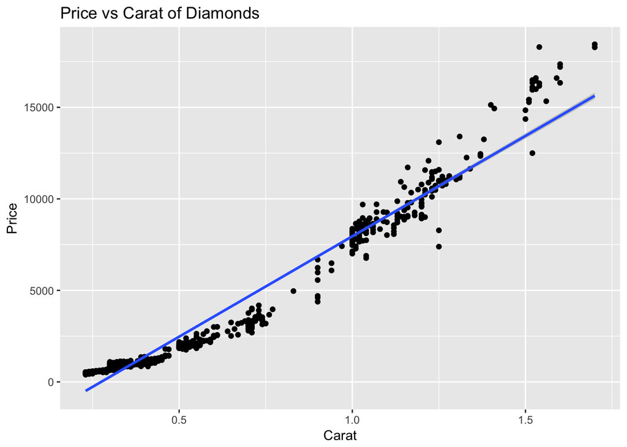

```r
#先挑選出顏色是G且淨度是VVS1的鑽石資料為dd
dd <- subset(diamonds, color == "G" & clarity == "VVS1")
#作圖並加上linear model的回歸曲線
ggplot(dd, aes(x = carat, y = price))+geom_point()+geom_smooth(method ="lm")+ ggtitle("Price vs Carat of Diamonds")+ xlab("Carat")+ ylab("Price")
```

或者想了解不同切工克拉數與價格的關係。

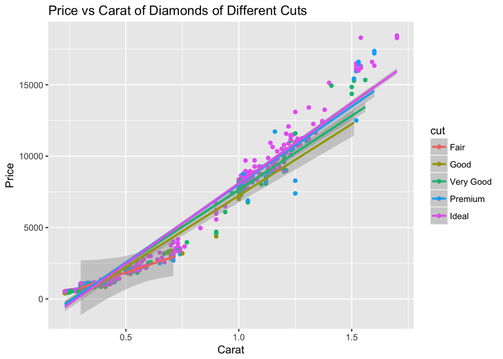

```r
#將鑽石的不同切工（cut）分開作圖並加上linear model的回歸曲線
ggplot(dd, aes(x = carat, y = price, color = cut))+geom_point()+geom_smooth(method ="lm")+ggtitle("Price vs Carat of Diamonds of Different Cuts")+ xlab("Carat")+ ylab("Price")
```

# 2. 線圖

```r
head(airmiles)
```

```
## [1]  412  480  683 1052 1385 1418
```

說明：`airmiles`是1937年到1960年共24年間美國旅客航空的里程數變化。

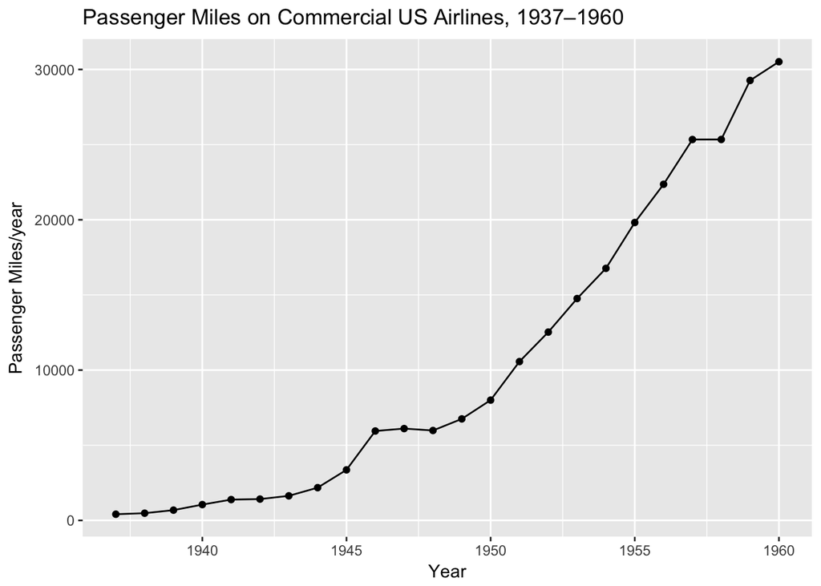

```r
airmiles_num <- as.numeric(airmiles)
airmiles_df <- data.frame(airmiles_num)
ggplot(airmiles_df, aes(x =1937:1960, y = airmiles))+geom_line()+geom_point() + xlab("Year")+ ylab("Passenger Miles/year")+ ggtitle("Passenger Miles on Commercial US Airlines, 1937–1960")
```

# 3.直方圖

說明：探討顏色是G且淨度是VVS1的0.4-0.6克拉鑽石的價格分佈

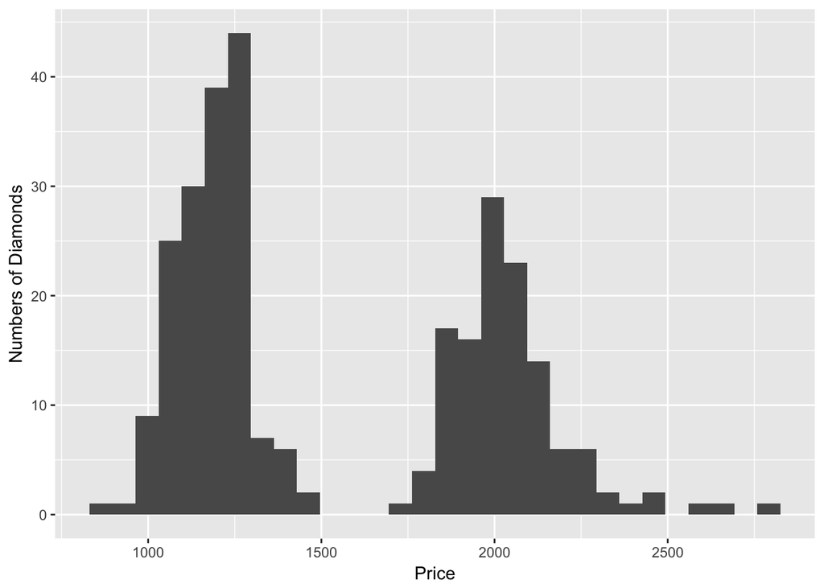

```r
dd_carat46 <- dd[dd$carat<0.6& dd$carat>=0.4,]
ggplot(dd_carat46, aes(x= price)) + geom_histogram()+xlab("Price")+ylab("Numbers of Diamonds")
```

或者將不同的切工分別做圖，看顏色是G且淨度是VVS1的0.4-0.6克拉鑽石的價格分佈

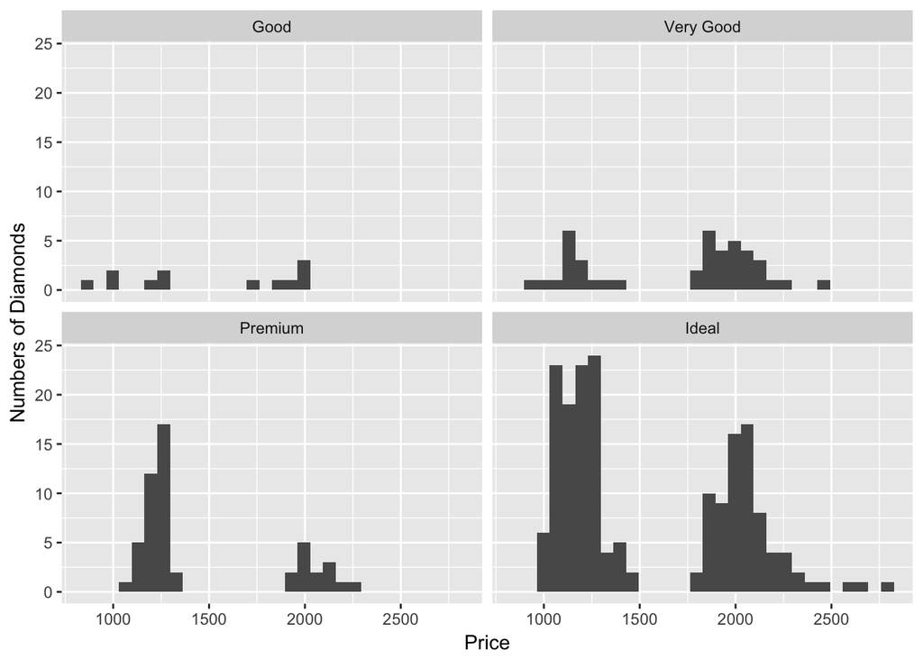

```r
ggplot(dd_carat46, aes(x= price)) + geom_histogram() + facet_wrap(~ cut)+xlab("Price")+ylab("Numbers of Diamonds")
```

# 4. 盒鬚圖

說明：探討顏色是G且淨度是VVS1的0.4-0.6克拉鑽石的價格分佈

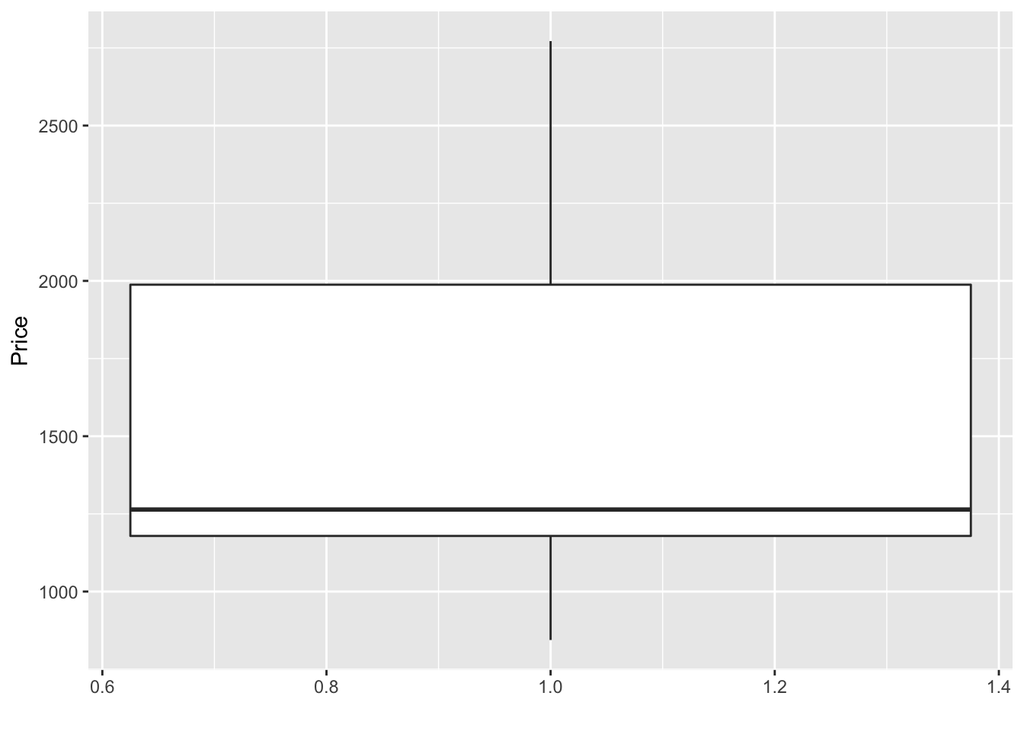

```r
ggplot(dd_carat46,aes(x = 1, y =price)) + geom_boxplot()+ylab("Price")+xlab("")
```

或者探討不同的切工，顏色是G且淨度是VVS1的0.4-0.6克拉鑽石的價格分佈

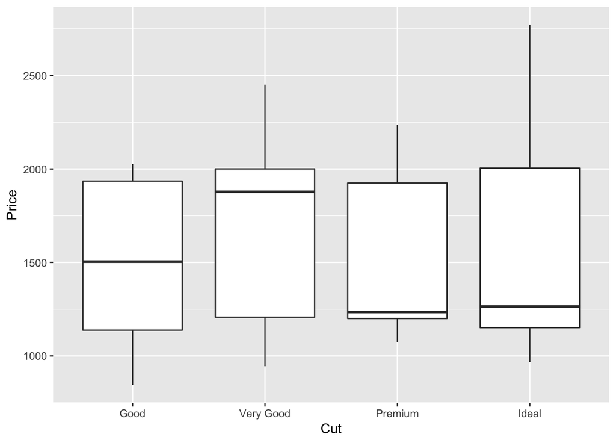

```r
ggplot(dd_carat46,aes(x = cut, y =price)) + geom_boxplot()+ylab("Price")+xlab("Cut")
```

# 5. 長條圖

說明：顏色是G且淨度是VVS1的0.4-0.6克拉鑽石不同切工的個數

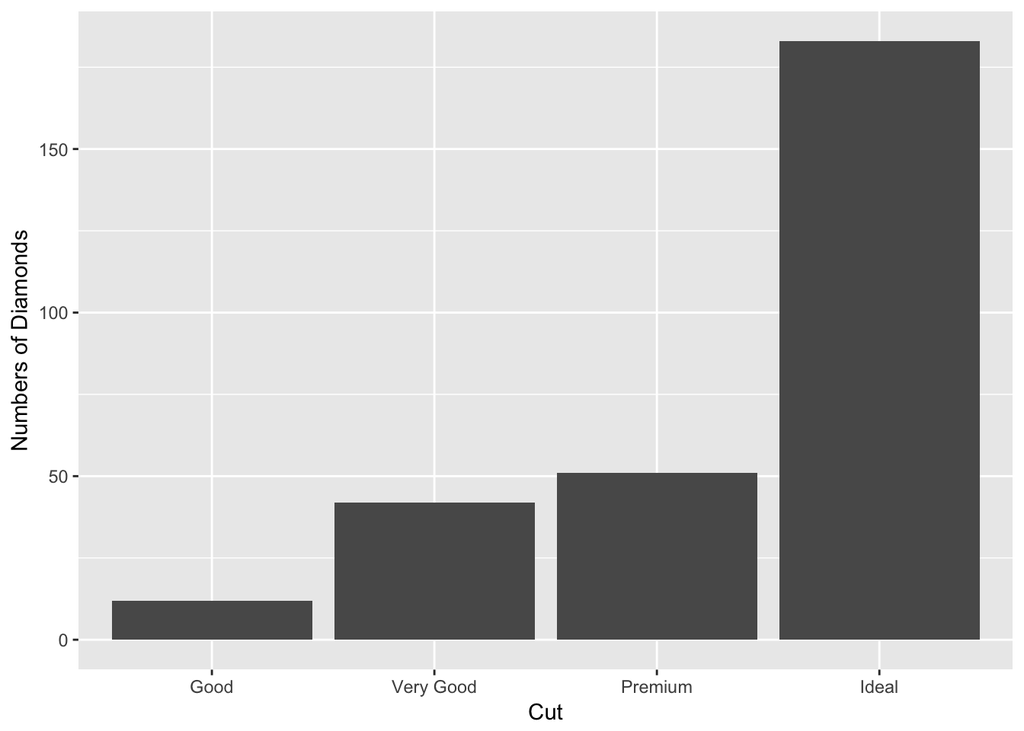

```r
ggplot(dd_carat46, aes(x = cut))+geom_bar()+xlab("Cut")+ylab("Numbers of Diamonds")
```

或者用`plotly`繪製資料中所有鑽石不同切工的個數的互動長條圖

```r
ggplotly(ggplot(diamonds, aes(x = cut))+geom_bar(aes(fill=color),position="dodge") + xlab("Cut")+ylab("Numbers of Diamonds"))
```

[interactive chart not shown]